|  | Home | EDA Cleanse | EDA Analysis | Feature Engineering | ML Models - Logistical Regression | ML Models - Decision Tree | ML Models - Random Forest | Model Demonstration |
| --- | --- | --- | --- | --- | --- | --- | --- | --- |

# Salifort Motors - EDA Data Cleansing

### Document Information

| Document Title | Salifort Motors - EDA Data Cleansing |
| --- | --- |
| Author | Rod Slater |
| Version | 1.0 |
| Created | 01-11-2023 |
| Modified | 16-11-2023 |

### [Client Details](#toc0_)

| Client Name | Salifort Motors |
| --- | --- |
| Client Contact | Mr HR Team |
| Client Email | hr@salifortmotors.it |
| Client Project | HR Team Data Driven Solutions from Machine Learning Models |

### Document Overview

EDA Data Cleansing notebook for HR Data provided by Salifort Motors. This notebook details the steps taken to clean the data prior to data analysis.

## Data Provenance

- First party data supplied directly to us by the client
- Bias Features :
  - Protected Groups : There's no data relating to : gender, age, religion, disability in the provided data
  - Selection Bias : Data represents employees of the client
  - Non Response Bias : We do not know if this is a complete data set
  - Historical Bias : There is potential for historical bias from `last_evaluation` score which is sourced from the team manager
  - Selection Bias : Train/Test split will reduce the potential impact of selection bias by randomising data used for training and separate it from testing data
  - PII: There is no personally identifiable information in the data set

### Data PreProcessing

- Clean columns names apply snake_case
- Remove Duplicates
- Remove missing values
- Review and remove outliers if required for a specific ML model.
- Review if encoding for categorical features is required
- Salifort Motors - EDA Data Cleansing
  - Document Information
  - Client Details
  - Document Overview
  - Data Provenance
    - Data PreProcessing
- - Initialise Notebook
    - Import packages
    - Set Pandas Options
    - Initialise Notebook Options
  - Step 2. Data Exploration (Initial EDA and data cleaning)
    - Load dataset
  - Variable Information
    - Gather basic information about the data
    - Gather descriptive statistics about the data
    - Rename columns
    - Check missing values
    - Check duplicates
      - Check for class imbalance before removing duplicates
      - Check class balance of duplicated rows
- Check categorical values for consistency
- Correct categorical values for snake_case
  - Save df1 dataFrame : Minimal Feature Engineering - Duplicates removed
  - Check outliers
  - Save df1 dataFrame : Duplicates removed, `tenure` outliers removed

## Initialise Notebook

- Import packages
- Load dataset

### Import packages

```python
# Import packages

# Data manipulation
import numpy as np
import pandas as pd

# Data visualization
import matplotlib.pyplot as plt
import seaborn as sns

# Set Options
pd.set_option('display.max_columns', None)

# Data modelling Imports
from xgboost import XGBClassifier, XGBRegressor, plot_importance

from sklearn.linear_model import LogisticRegression
from sklearn.tree import DecisionTreeClassifier
from sklearn.ensemble import RandomForestClassifier

# For metrics and helpful functions
from sklearn.model_selection import GridSearchCV, train_test_split
from sklearn.metrics import accuracy_score, precision_score, recall_score,\
f1_score, confusion_matrix, ConfusionMatrixDisplay, classification_report
from sklearn.metrics import roc_auc_score, roc_curve
from sklearn.tree import plot_tree

# For saving models
import pickle
```

### Set Pandas Options

```python
# set Pandas Display Options
pd.options.display.float_format = '{:.2f}'.format
pd.set_option('display.precision', 2)
pd.set_option('display.max_columns', None)
pd.set_option('display.width', 120)
```

### Initialise Notebook Options

```python
load_path = "/home/hass/Documents/Learning/Salifort-Motors-Capstone-Project/00-data_source/"
save_path = "/home/hass/Documents/Learning/Salifort-Motors-Capstone-Project/00-data_cleaned/"
```

## Data Exploration (Initial EDA and data cleaning)

### Load dataset

```python
# Load dataset into a dataframe

df0 = pd.read_csv(load_path + "HR_capstone_dataset.csv")


# Display first few rows of the dataframe

df0.head()
```

|  | satisfaction_level | last_evaluation | number_project | average_montly_hours | time_spend_company | Work_accident | left | promotion_last_5years | Department | salary |
| --- | --- | --- | --- | --- | --- | --- | --- | --- | --- | --- |
| 0 | 0.38 | 0.53 | 2 | 157 | 3 | 0 | 1 | 0 | sales | low |
| 1 | 0.80 | 0.86 | 5 | 262 | 6 | 0 | 1 | 0 | sales | medium |
| 2 | 0.11 | 0.88 | 7 | 272 | 4 | 0 | 1 | 0 | sales | medium |
| 3 | 0.72 | 0.87 | 5 | 223 | 5 | 0 | 1 | 0 | sales | low |
| 4 | 0.37 | 0.52 | 2 | 159 | 3 | 0 | 1 | 0 | sales | low |

## Variable Information

| Variable | Description |
| --- | --- |
| satisfaction_level | Employee-reported job satisfaction level [0&ndash;1] |
| last_evaluation | Score of employee's last performance review [0&ndash;1] |
| number_project | Number of projects employee contributes to |
| average_monthly_hours | Average number of hours employee worked per month |
| time_spend_company | How long the employee has been with the company (years) |
| Work_accident | Whether or not the employee experienced an accident while at work |
| left | Whether or not the employee left the company |
| promotion_last_5years | Whether or not the employee was promoted in the last 5 years |
| Department | The employee's department |
| salary | The employee's salary (U.S. dollars) |

### Gather basic information about the data

```python
# Gather basic information about the data

df0.info()
```

```
<class 'pandas.core.frame.DataFrame'>
RangeIndex: 14999 entries, 0 to 14998
Data columns (total 10 columns):
 #   Column                 Non-Null Count  Dtype
---  ------                 --------------  -----
 0   satisfaction_level     14999 non-null  float64
 1   last_evaluation        14999 non-null  float64
 2   number_project         14999 non-null  int64
 3   average_montly_hours   14999 non-null  int64
 4   time_spend_company     14999 non-null  int64
 5   Work_accident          14999 non-null  int64
 6   left                   14999 non-null  int64
 7   promotion_last_5years  14999 non-null  int64
 8   Department             14999 non-null  object
 9   salary                 14999 non-null  object
dtypes: float64(2), int64(6), object(2)
memory usage: 1.1+ MB
```

### Gather descriptive statistics about the data

```python
# Gather descriptive statistics about the data

df0.describe(include='all')
```

|  | satisfaction_level | last_evaluation | number_project | average_montly_hours | time_spend_company | Work_accident | left | promotion_last_5years | Department | salary |
| --- | --- | --- | --- | --- | --- | --- | --- | --- | --- | --- |
| count | 14999.00 | 14999.00 | 14999.00 | 14999.00 | 14999.00 | 14999.00 | 14999.00 | 14999.00 | 14999 | 14999 |
| unique | NaN | NaN | NaN | NaN | NaN | NaN | NaN | NaN | 10 | 3 |
| top | NaN | NaN | NaN | NaN | NaN | NaN | NaN | NaN | sales | low |
| freq | NaN | NaN | NaN | NaN | NaN | NaN | NaN | NaN | 4140 | 7316 |
| mean | 0.61 | 0.72 | 3.80 | 201.05 | 3.50 | 0.14 | 0.24 | 0.02 | NaN | NaN |
| std | 0.25 | 0.17 | 1.23 | 49.94 | 1.46 | 0.35 | 0.43 | 0.14 | NaN | NaN |
| min | 0.09 | 0.36 | 2.00 | 96.00 | 2.00 | 0.00 | 0.00 | 0.00 | NaN | NaN |
| 25% | 0.44 | 0.56 | 3.00 | 156.00 | 3.00 | 0.00 | 0.00 | 0.00 | NaN | NaN |
| 50% | 0.64 | 0.72 | 4.00 | 200.00 | 3.00 | 0.00 | 0.00 | 0.00 | NaN | NaN |
| 75% | 0.82 | 0.87 | 5.00 | 245.00 | 4.00 | 0.00 | 0.00 | 0.00 | NaN | NaN |
| max | 1.00 | 1.00 | 7.00 | 310.00 | 10.00 | 1.00 | 1.00 | 1.00 | NaN | NaN |

### Rename columns

As a data cleaning step, rename the columns as needed. Standardize the column names so that they are all in `snake_case`, correct any column names that are misspelled, and make column names more concise as needed.

```python
# Display all column names

df0.columns
```

```
Index(['satisfaction_level', 'last_evaluation', 'number_project', 'average_montly_hours', 'time_spend_company',
       'Work_accident', 'left', 'promotion_last_5years', 'Department', 'salary'],
      dtype='object')
```

```python
# Rename columns as needed
df0 = df0.rename(columns = {'satisfaction_level': 'satisfaction',
                            'last_evaluation' : 'last_eval',
                            'average_montly_hours': 'avg_mnth_hrs',
                            'time_spend_company': 'tenure',
                            'Work_accident': 'accident',
                            'Department': 'dept',
                            'promotion_last_5years': 'promotion'})


# Display all column names after the update
df0.columns
```

```
Index(['satisfaction', 'last_eval', 'number_project', 'avg_mnth_hrs', 'tenure', 'accident', 'left', 'promotion',
       'dept', 'salary'],
      dtype='object')
```

### Check missing values

Check for any missing values in the data.

There are no missing values

```python
# Check for missing values

df0.isna().sum()
```

```
satisfaction      0
last_eval         0
number_project    0
avg_mnth_hrs      0
tenure            0
accident          0
left              0
promotion         0
dept              0
salary            0
dtype: int64
```

### Check duplicates

Check for any duplicate entries in the data.

Of the 14,999 total rows in the table, 3008 (20%) appear to be duplicated.

```python
# Check for duplicates
df0.duplicated().sum()
```

```
3008
```

#### Check for class imbalance before removing duplicates

Before any cleaning is carried out we need to check the class balance for the target variable.

We can see a class imbalance

```python
print(df0['left'].value_counts())
print(df0['left'].value_counts(normalize=True))
```

```
left
0    11428
1     3571
Name: count, dtype: int64
left
0   0.76
1   0.24
Name: proportion, dtype: float64
```

#### Check class balance of duplicated rows

Before removing any duplicated rows, we need to check the balance of the duplicated rows.

```python
# showing the duplicate values
df_duplicated=df0[df0.duplicated()==True]
print(df_duplicated['left'].value_counts())
print(df_duplicated['left'].value_counts(normalize=True))
```

```
left
1    1580
0    1428
Name: count, dtype: int64
left
1   0.53
0   0.47
Name: proportion, dtype: float64
```

```python
# Inspect some rows containing duplicates as needed

df_duplicated.sample(20)
```

|  | satisfaction | last_eval | number_project | avg_mnth_hrs | tenure | accident | left | promotion | dept | salary |
| --- | --- | --- | --- | --- | --- | --- | --- | --- | --- | --- |
| 12460 | 0.43 | 0.49 | 2 | 135 | 3 | 0 | 1 | 0 | accounting | medium |
| 13709 | 0.56 | 0.66 | 4 | 264 | 3 | 0 | 0 | 0 | sales | low |
| 14462 | 0.79 | 0.92 | 5 | 254 | 6 | 0 | 1 | 0 | sales | low |
| 12897 | 0.62 | 0.95 | 4 | 140 | 2 | 0 | 0 | 0 | accounting | low |
| 14875 | 0.36 | 0.49 | 2 | 147 | 3 | 0 | 1 | 0 | marketing | low |
| 12525 | 0.41 | 0.56 | 2 | 150 | 3 | 0 | 1 | 0 | product_mng | low |
| 14325 | 0.84 | 1.00 | 5 | 234 | 5 | 0 | 1 | 0 | technical | medium |
| 14019 | 0.69 | 0.90 | 5 | 103 | 5 | 0 | 0 | 0 | product_mng | low |
| 13367 | 0.80 | 0.74 | 3 | 228 | 3 | 0 | 0 | 0 | technical | medium |
| 12892 | 0.82 | 0.49 | 4 | 180 | 2 | 0 | 0 | 0 | RandD | low |
| 14433 | 0.37 | 0.51 | 2 | 153 | 3 | 0 | 1 | 0 | product_mng | low |
| 13778 | 0.61 | 0.82 | 4 | 184 | 8 | 0 | 0 | 0 | IT | low |
| 13386 | 0.57 | 0.39 | 4 | 132 | 3 | 0 | 0 | 0 | product_mng | high |
| 13479 | 0.49 | 0.77 | 3 | 211 | 3 | 0 | 0 | 0 | IT | high |
| 13160 | 0.49 | 0.67 | 3 | 140 | 2 | 0 | 0 | 0 | hr | medium |
| 14554 | 0.41 | 0.56 | 2 | 143 | 3 | 0 | 1 | 0 | technical | medium |
| 12269 | 0.38 | 0.86 | 6 | 139 | 6 | 0 | 1 | 0 | technical | medium |
| 14635 | 0.45 | 0.46 | 2 | 130 | 3 | 0 | 1 | 0 | technical | low |
| 14451 | 0.10 | 0.87 | 7 | 289 | 4 | 0 | 1 | 0 | sales | low |
| 12299 | 0.74 | 0.84 | 5 | 249 | 5 | 0 | 1 | 0 | product_mng | medium |

```python
# Drop duplicates and save resulting dataframe in a new variable as needed

print("Pre De-dupe Rows  : ",df0.shape[0])
df1 = df0.drop_duplicates(keep = 'first')
df1.reset_index(inplace=True, drop=True)

# Display first few rows of new dataframe as needed

print("Post De-dupe Rows : ",df1.shape[0])
print("De-dupe rows removed   : ", df0.shape[0] - df1.shape[0])
df1.head()
```

[output not shown]

|  | satisfaction | last_eval | number_project | avg_mnth_hrs | tenure | accident | left | promotion | dept | salary |
| --- | --- | --- | --- | --- | --- | --- | --- | --- | --- | --- |
| 0 | 0.38 | 0.53 | 2 | 157 | 3 | 0 | 1 | 0 | sales | low |
| 1 | 0.80 | 0.86 | 5 | 262 | 6 | 0 | 1 | 0 | sales | medium |
| 2 | 0.11 | 0.88 | 7 | 272 | 4 | 0 | 1 | 0 | sales | medium |
| 3 | 0.72 | 0.87 | 5 | 223 | 5 | 0 | 1 | 0 | sales | low |
| 4 | 0.37 | 0.52 | 2 | 159 | 3 | 0 | 1 | 0 | sales | low |

# Check categorical values for consistency

```python
print(df1['salary'].unique())
print(df1['dept'].unique())
```

```
['low' 'medium' 'high']
['sales' 'accounting' 'hr' 'technical' 'support' 'management' 'IT'
 'product_mng' 'marketing' 'RandD']
```

# Correct categorical values for snake_case

```python
df1.loc[:,'dept'] = df1['dept'].str.lower()
```

## Save df1 dataFrame : Minimal Feature Engineering - Duplicates removed

```python
# Save dataframe to CSV, full dataframe, with tenure outliers, no duplicates, No Feature Engineering

df1.to_csv(save_path + 'salifort_data_cleaned_all.csv', encoding='utf-8', index=False)
df1.shape
```

```
(11991, 10)
```

## Check outliers

Check for outliers in the data.

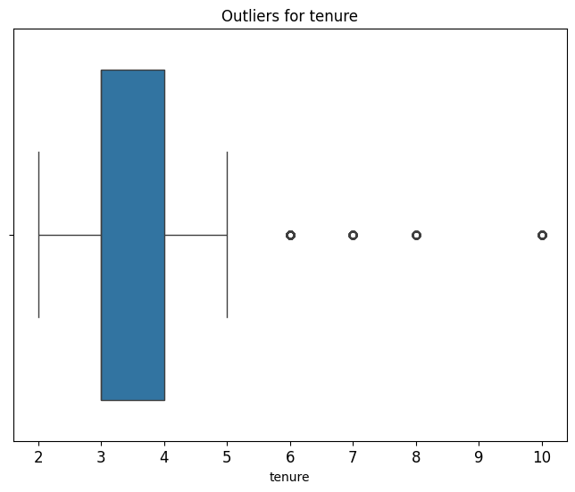

```python
# Create a boxplot to visualize distribution of `tenure` and detect any outliers
plt.figure(figsize = (8,6))
plt.title('Outliers for tenure', fontsize = 12)
plt.xticks(fontsize = 12)
plt.yticks(fontsize = 12)
sns.boxplot(x = df1['tenure'])
plt.show()
```

```python
# Calculate percentiles and Interquartile range :
# The interquartile range (IQR) is a measure of statistical dispersion that
# describes the spread or variability of a dataset.

# Calculate 25th percentile

print(df1.shape)
perc25 = df1['tenure'].quantile(0.25)

#calculate 75th percentile
perc75 = df1['tenure'].quantile(0.75)

#Calculate the IQR (Interquartile Range)
iqr = perc75 - perc25

#Define the upper limit and lower limit for non-outlier values in 'tenure'
upper_limit = perc75 + 1.5 * iqr
lower_limit = perc25 - 1.5 * iqr


# subset data containing outliers
outliers = df1[(df1['tenure'] > upper_limit) | (df1['tenure'] < lower_limit)]
num_df_rows = df1.shape[0]
num_outliers = len(outliers)
perc_outliers = num_outliers / num_df_rows * 100

# Summary

print("IQR                  :   ", iqr)
print("Lower limit          :   ", lower_limit)
print("Upper limit          :   ", upper_limit)
print("# rows with outliers : ", num_outliers)
print("% rows with outliers :    {:.2f} %".format(perc_outliers))
```

```
(11991, 10)
IQR                  :    1.0
Lower limit          :    1.5
Upper limit          :    5.5
# rows with outliers :  824
% rows with outliers :    6.87 %
```

```python
# REMOVE OUTLIERS
print(df1.shape)
# Remove records from df1 that are in df2
df1 = df1[~df1.isin(outliers)].dropna()

# Reset the index of the modified DataFrame (optional)
df1.reset_index(drop=True, inplace=True)
print(df1.shape)
```

```
(11991, 10)
(11167, 10)
```

## Save df1 dataFrame : Duplicates removed, `tenure` outliers removed

Some types of ML models (Notably Regression models) are more sensitive to outliers than others.

```python
df1.to_csv(save_path + 'salifort_data_cleaned_no_ol.csv', encoding='utf-8', index=False)

df1.shape
```

```
(11167, 10)
```